# Task13

Linas Šyvis

# 1.

**Sąlyga:**

For the following series, find an appropriate Box-Cox transformation and order of differencing in order to obtain stationary data.

1. usnetelec
2. usgdp
3. mcopper
4. enplanements
5. visitors

# Programos kodas

Visų pirma, įsirašome paketą {fpp}. Jame esančius duomenis naudosime užduotyje.

```r
library(fpp)
```

Išbrėžkime pradinių duomenų (juoda) ir duomenų po transformacijos ir diferencijavimo (raudona) grafikus:

**(a) usnetelec**

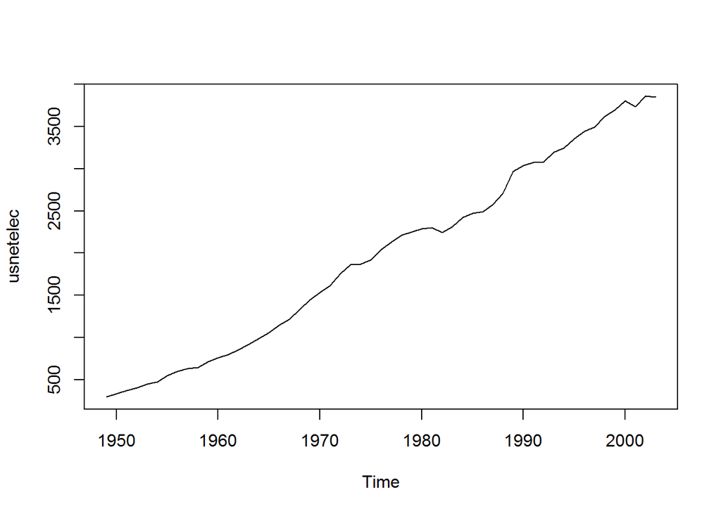

```r
lambda1 <- BoxCox.lambda(usnetelec)#randame Box-Cox transformacijos parametrą lambda
plot(usnetelec)
```

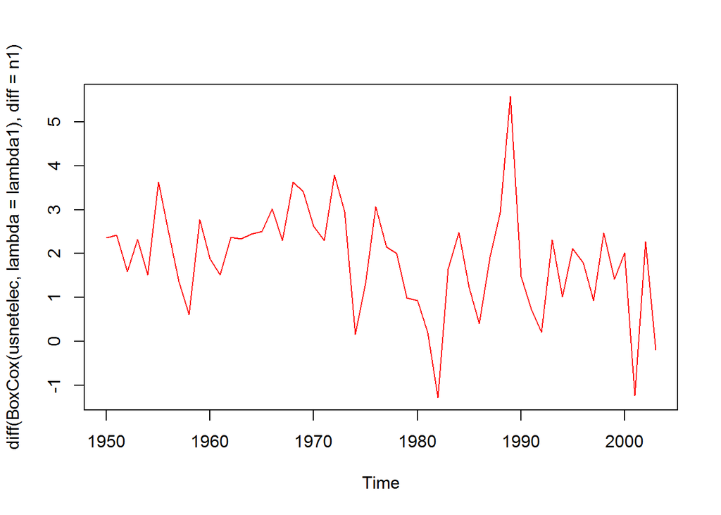

```r
n1 <- ndiffs(usnetelec)
plot(diff(BoxCox(usnetelec, lambda=lambda1), diff = n1), col = "red")
```

Funkcija ndiffs pasiūlo, kiek kartų duomenis būtų geriausia diferencijuoti. Išbrėžus duomenis po transformacijos ir pirmos eilės diferencijavimo pastebime, kad galimai nėra stacionarumo. Patikrinkime šį spėjimą su KPSS testu su nuline hipoteze, kad duomenys yra stacionarūs su alternatyva, kad nėra.

```r
kpss.test(diff(BoxCox(usnetelec,lambda=lambda1), diff = n1))
```

```
##
##  KPSS Test for Level Stationarity
##
## data:  diff(BoxCox(usnetelec, lambda = lambda1), diff = n1)
## KPSS Level = 0.48507, Truncation lag parameter = 1, p-value =
## 0.04503
```

p-value < 0.05, H0 atmetam, remiantis KPSS testu, iš tikrųjų, duomenys nėra stacionarūs.

Diferencijuokime duomenis dukart, galbūt tada atsiras stacionarumas:

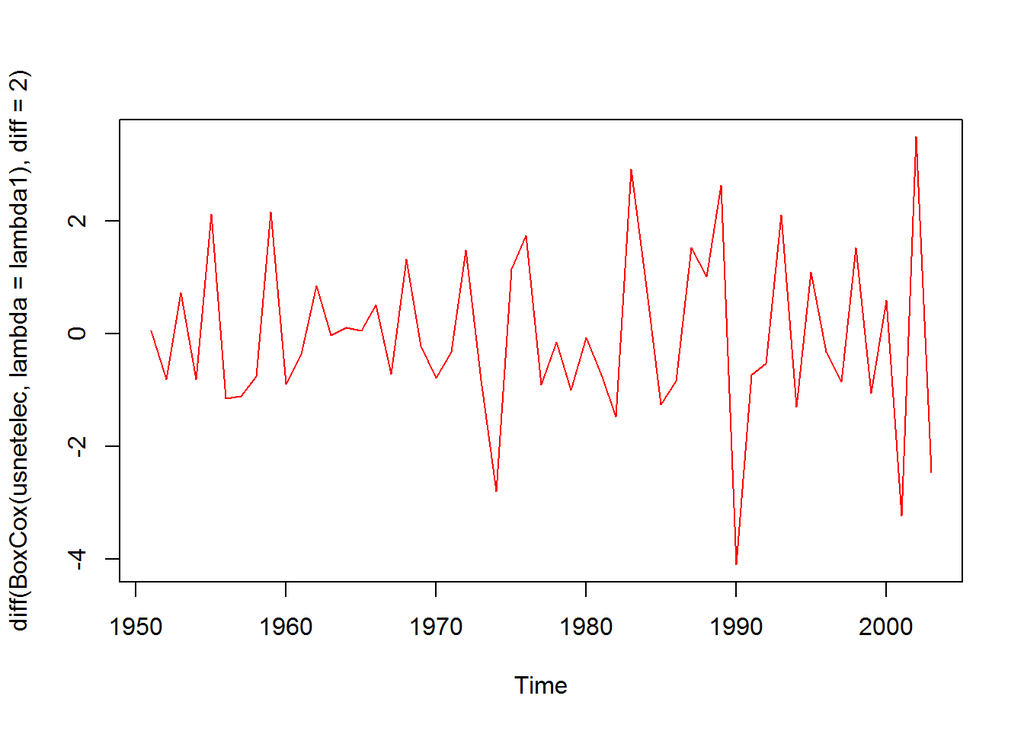

```r
plot(diff(BoxCox(usnetelec, lambda=lambda1), diff = 2), col = "red")
```

```r
kpss.test(diff(BoxCox(usnetelec,lambda=lambda1), diff = 2))
```

```
##
##  KPSS Test for Level Stationarity
##
## data:  diff(BoxCox(usnetelec, lambda = lambda1), diff = 2)
## KPSS Level = 0.029211, Truncation lag parameter = 1, p-value = 0.1
```

Iš grafiko matome, kad duomenys tapo panašesni į stacionarius, o atliktas testas patvirtina (p-value > 0.05) mūsų spėjimą.

**(b) usgdp**

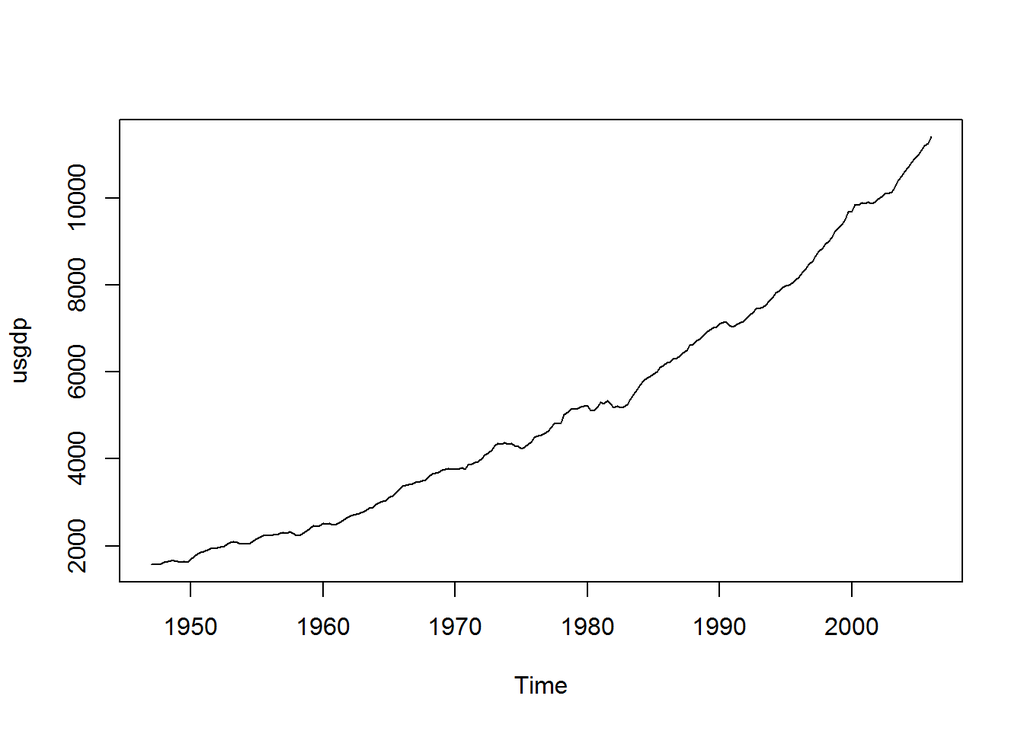

```r
lambda2 <- BoxCox.lambda(usgdp)#randame Box-Cox transformacijos parametrą lambda
n2 <- ndiffs(usgdp)
plot(usgdp)
```

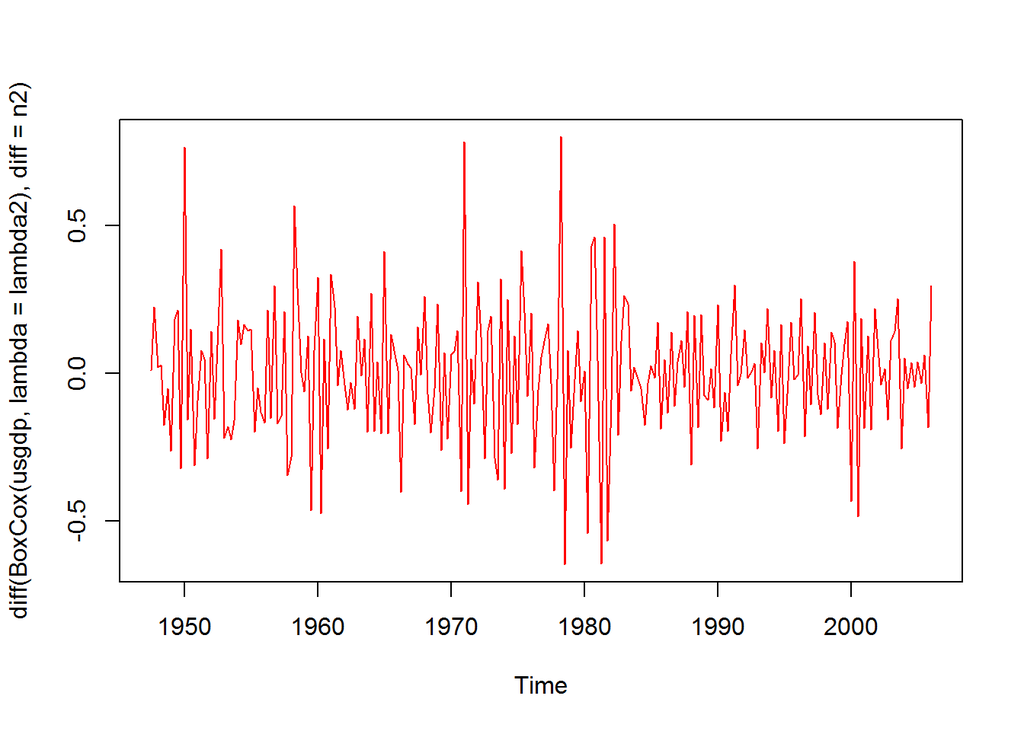

```r
plot(diff(BoxCox(usgdp,lambda=lambda2), diff = n2), col = "red")
```

```r
kpss.test(diff(BoxCox(usgdp,lambda=lambda2), diff = n2))
```

```
##
##  KPSS Test for Level Stationarity
##
## data:  diff(BoxCox(usgdp, lambda = lambda2), diff = n2)
## KPSS Level = 0.010286, Truncation lag parameter = 3, p-value = 0.1
```

Išbrėžus grafiką po transformacijos ir po funkcijos ndiffs pasiūlyto antros eilės diferencijavimo, gauname stacionarius duomenis.

**(c) mcopper**

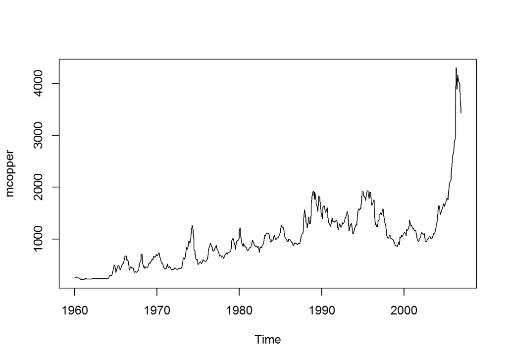

```r
lambda3 <- BoxCox.lambda(mcopper)#randame Box-Cox transformacijos parametrą lambda
n3 <- ndiffs(mcopper)
plot(mcopper)
```

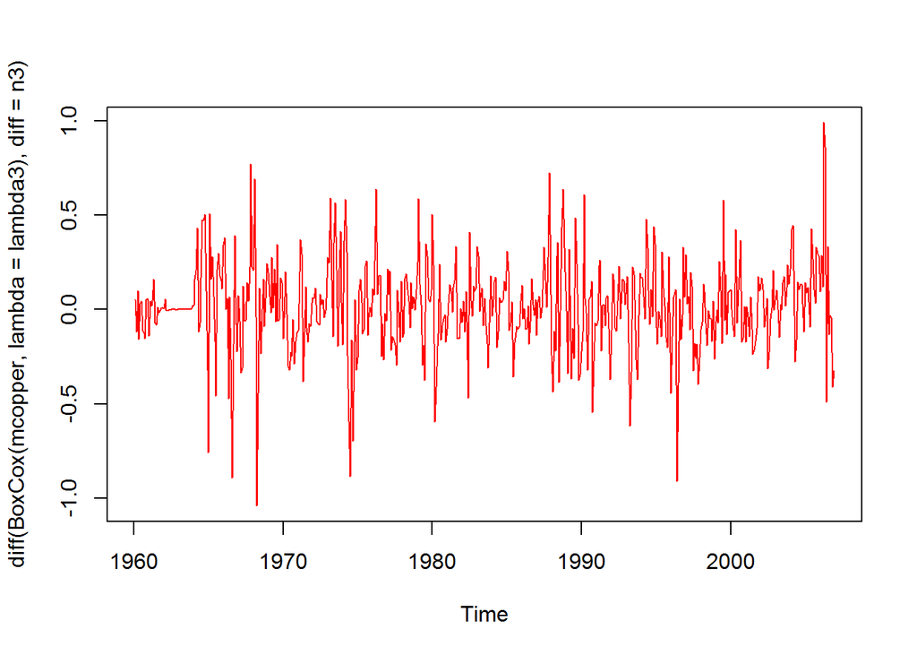

```r
plot(diff(BoxCox(mcopper,lambda=lambda3), diff = n3), col = "red")
```

```r
kpss.test(diff(BoxCox(mcopper,lambda=lambda3), diff = n3))
```

```
##
##  KPSS Test for Level Stationarity
##
## data:  diff(BoxCox(mcopper, lambda = lambda3), diff = n3)
## KPSS Level = 0.058427, Truncation lag parameter = 5, p-value = 0.1
```

Išbrėžus grafiką po transformacijos ir po funkcijos ndiffs pasiūlyto pirmos eilės diferencijavimo, gauname stacionarius duomenis.

**(d) enplanements**

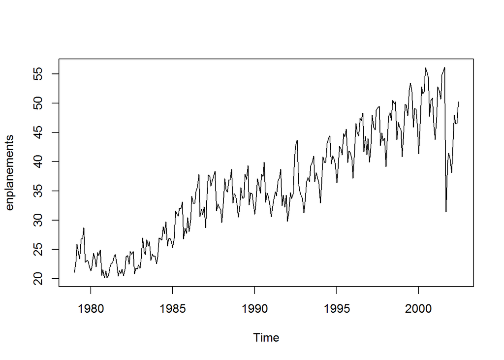

```r
lambda4 <- BoxCox.lambda(enplanements)#randame Box-Cox transformacijos parametrą lambda
n4 <- nsdiffs(enplanements)
plot(enplanements)
```

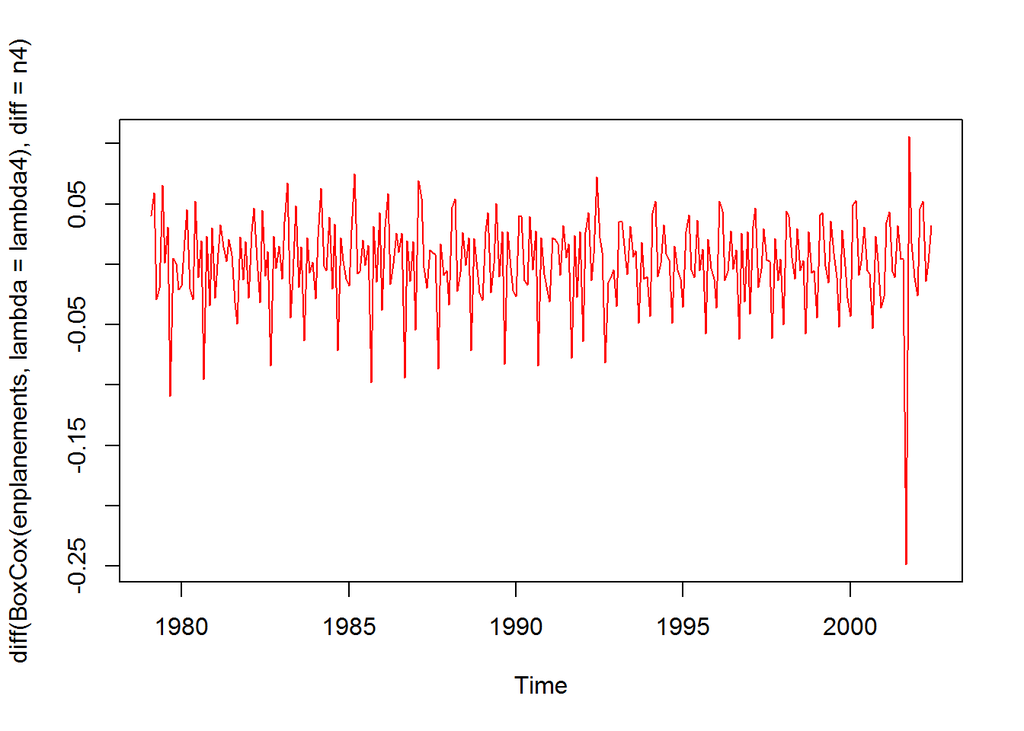

```r
plot(diff(BoxCox(enplanements,lambda=lambda4), diff = n4), col = "red")
```

```r
kpss.test(diff(BoxCox(enplanements,lambda=lambda4), diff = n4))
```

```
##
##  KPSS Test for Level Stationarity
##
## data:  diff(BoxCox(enplanements, lambda = lambda4), diff = n4)
## KPSS Level = 0.01656, Truncation lag parameter = 3, p-value = 0.1
```

Šįkart naudosime funkciją nsdiffs, nes duomenyse yra sezoniškumas. Išbrėžus grafiką po transformacijos ir po funkcijos nsdiffs pasiūlyto pirmos eilės diferencijavimo, gauname stacionarius duomenis.

**(e) visitors**

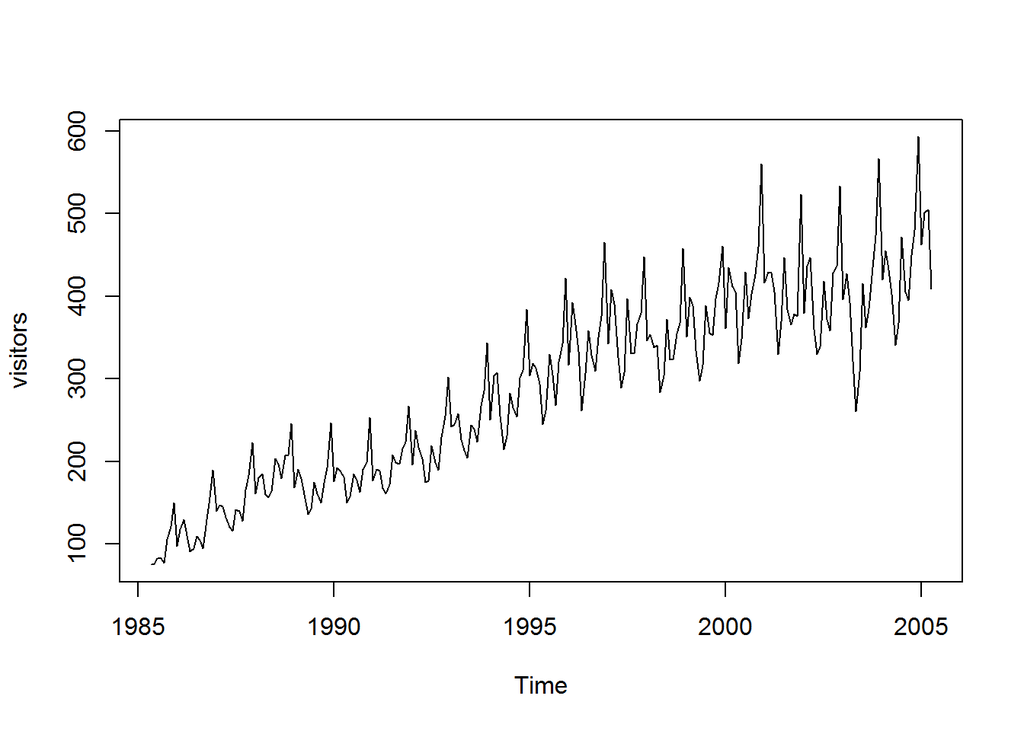

```r
lambda5 <- BoxCox.lambda(visitors)#randame Box-Cox transformacijos parametrą lambda
n5 <- nsdiffs(visitors)
plot(visitors)
```

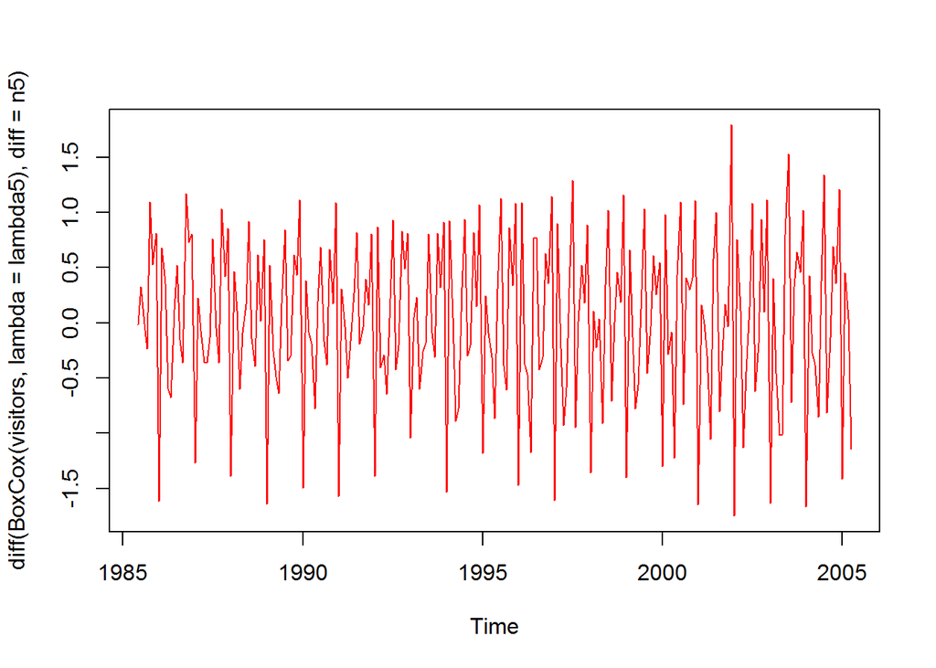

```r
plot(diff(BoxCox(visitors,lambda=lambda5), diff = n5), col = "red")
```

```r
kpss.test(diff(BoxCox(visitors,lambda=lambda5), diff = n5))
```

```
##
##  KPSS Test for Level Stationarity
##
## data:  diff(BoxCox(visitors, lambda = lambda5), diff = n5)
## KPSS Level = 0.052596, Truncation lag parameter = 3, p-value = 0.1
```

Išbrėžus grafiką po transformacijos ir po funkcijos nsdiffs pasiūlyto pirmos eilės diferencijavimo, gauname stacionarius duomenis.

- Išvada: Box-Cox transformacija ir diferencijavimas duomenis padaro stacionariais. Grafike stebimi duomenų pokyčiai, o ne reikšmių išsidėstymas laike.

# 2.

**Sąlyga:**

Why is a Box-Cox transformation unhelpful for the cangas data?

# Programos kodas

Išbrėžkime pradinių duomenų (juoda) ir duomenų po transformacijos (raudona) grafikus:

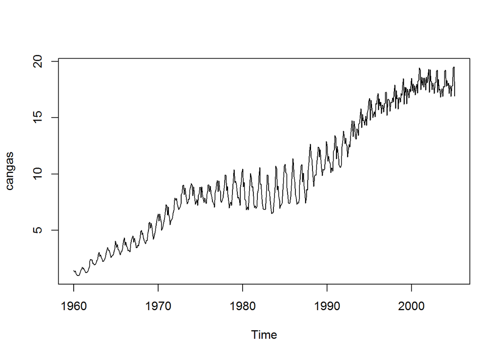

```r
lambda6 <- BoxCox.lambda(cangas)#randame Box-Cox transformacijos parametrą lambda
plot(cangas)
```

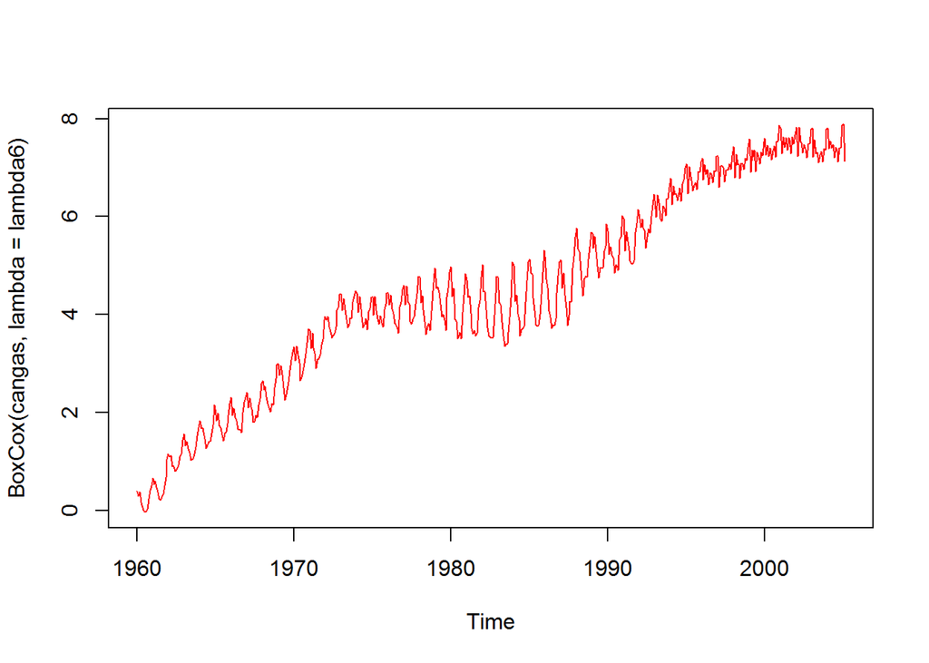

```r
plot(BoxCox(cangas,lambda=lambda6), col = "red")
```

Box-Cox transformacija šiuo atveju nėra naudinga, nes pradiniai duomenys pradžioje ir pabaigoje svyruoja mažai, o per vidurį svyravimai yra didžiausi. Tokiu atveju Box-Cox transformacija išlygina svyravimus tik pradžioje ir pabaigoje, o viduryje jie vis tiek išlieka dideli.

# 3.

**Sąlyga:**

Download the data at http://robjhyndman.com/data/retail.xls. Choose one of the series and find an appropriate Box-Cox transformation and order of differencing in order to obtain stationary data.

# Programos kodas

Nuskaitome duomenis.

```r
data = read.csv2("retail.csv", header = TRUE)
duomenys <- data[,2]#naudosime tik vieną duomenų stulpelį
duom <- ts(duomenys, frequency=12, start=c(1982,4))#išsaugome duomenis kaip laiko eilutę
```

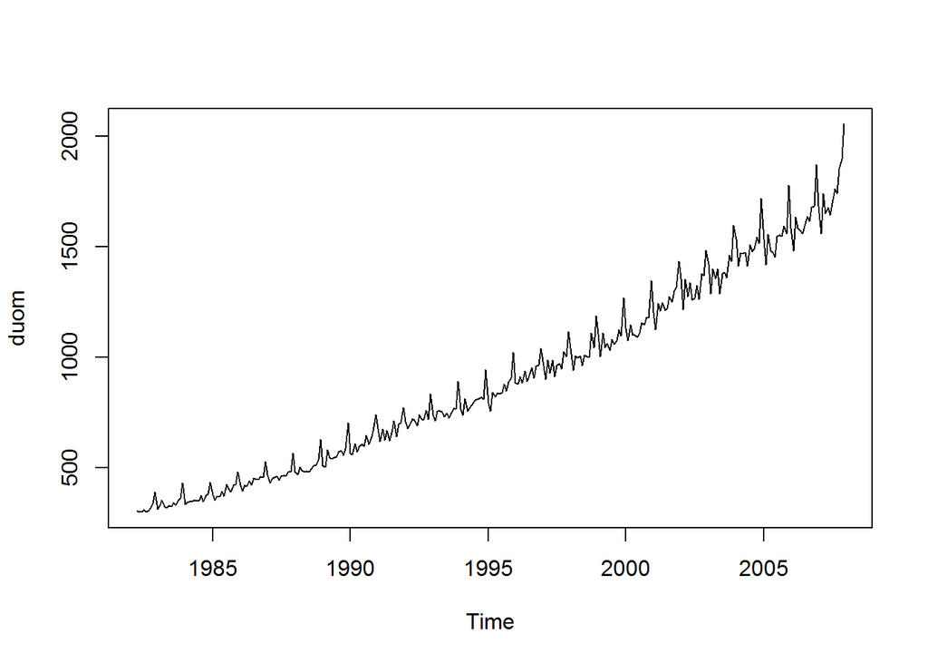

```r
lambda7 <- BoxCox.lambda(duom)#randame Box-Cox transformacijos parametrą lambda
n7 <- nsdiffs(duom)
plot(duom)
```

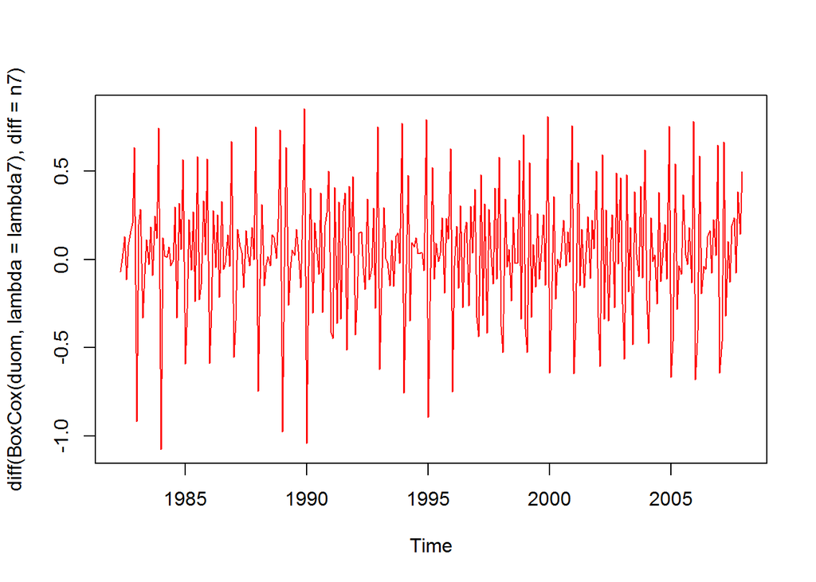

```r
plot(diff(BoxCox(duom,lambda = lambda7), diff = n7), col = "red")
```

```r
kpss.test(diff(BoxCox(duom,lambda=lambda7), diff = n7))
```

```
##
##  KPSS Test for Level Stationarity
##
## data:  diff(BoxCox(duom, lambda = lambda7), diff = n7)
## KPSS Level = 0.028309, Truncation lag parameter = 4, p-value = 0.1
```

Išbrėžus grafiką po transformacijos ir po funkcijos nsdiffs pasiūlyto pirmos eilės diferencijavimo, gauname stacionarius duomenis.

- Išvada: Box-Cox transformacija ir diferencijavimas duomenis padaro stacionariais. Grafike stebimi duomenų pokyčiai, o ne reikšmių išsidėstymas laike.